# Tutorial

### Python 3 Tutorial

- Python3 is a programming language that can be used for many things including data analysis, machine learning, automation, and more!
- In order to run python files, they are stored as .py files and can be run by doing C:\Users\Your Name>python file.py in terminal
- Anaconda navigator is a toolkit that has many third party packages that are commonly used such as pandas, numpy, sci-kit learn, and many more!
- After installing anaconda navigator:
  - To run anaconda navigator (UI Based Approach) --> Search Ananconda Navigator in Windows Start Menu and search Anaconda Navigator
    - This may be slow to open on weaker systems
  - For an IDE based approach to using anaconda --> Search Spyder in Windows Start Menu -- or --
  - For a Notebook based approach --> open Jupyter-Notebook
    - Cell like structure

# Comments

- Comments can be used to describe what your are doing

To comment use # or ''' code '''

It does not get run by the python interpreter

```python
#This is a comment

'''
This is a comment
'''
```

```
'\nThis is a comment\n'
```

# Variables

- Variables are containers for storing data
- Its an assignemnt term referencing what you set it to

x = 5

x is a variable

```python
x = 5
```

```python
x
```

```
5
```

### Variable Types

- Varibles are automically assigned by python to have certain types like in excel or SQL

Text Types:

- str = string

Numerical Types:

- int = integer (1,2,3)
- float = floatation Point Number (1.5, 1.0, 5.3)

Sequence or Grouping Types:

- list = list of items [1,3,4,'hi']
- tuple = unchanging list of items (1,2,3,'hi')
- dict = dictionary or hashmap, key-value pairs {1:'first',2:'second'} (more on this later)

Boolean or T/F

- bool = boolean True/False

find the type of any variable using type()

- The user can change the types using built in data type functions

```python
x = 5
y = 6.0
z = 'hi'

print(type(x))
print(type(y))
print(type(z))
```

```
<class 'int'>
<class 'float'>
<class 'str'>
```

Can convert between types by casting specific type functions

```python
y = 6.0
print(type(y))
y = int(y)
print(type(y))
```

```
<class 'float'>
<class 'int'>
```

|  | Operator | Name | Example |
| --- | --- | --- | --- |
| + | Addition | x + y |  |
| - | Subtraction | x - y |  |
| * | Multiplication | x * y |  |
| / | Division | x / y |  |
| % | Modulus | x % y |  |
| ** | Exponentiation | x ** y |  |
| // | Floor division | x // y |  |

# Lists

Indexing starts at 0 can find the last value of list using -1, 2nd to last using -2, ect.

can slice a list using [firstvalue:lastvalue+1]

```python
thislist = ["apple", "banana", "cherry",'orange','peach','tangerine']
print(thislist)
```

```
['apple', 'banana', 'cherry', 'orange', 'peach', 'tangerine']
```

```python
print(thislist[0])
print(thislist[1])
print(thislist[-1])
```

```
apple
banana
tangerine
```

```python
print(thislist[1:4])
```

```
['banana', 'cherry', 'orange']
```

# Dictionaries

- Serve as a key-value pair collection
- A dictionary is a collection which is unordered, changeable and indexed. In Python dictionaries are written with curly brackets, and they have keys and values.

```python
thisdict = {
  "brand": "Ford",
  "model": "Mustang",
  "year": 1964
}
print(thisdict)
```

```
{'brand': 'Ford', 'model': 'Mustang', 'year': 1964}
```

Can access items by passing the key through the dict variable

```python
x = thisdict["model"]
print(x)
```

```
Mustang
```

In order to change values you can declare it similar to variable declaration but pass in the key and value you want

```python
thisdict["year"] = 2018
```

```python
thisdict
```

```
{'brand': 'Ford', 'model': 'Mustang', 'year': 2018}
```

# Conditional Statements

Conditionals can be used to print if a condition is true or can be used to set variables

INDENTATION MATTERS

```python
a = 200
b = 33
if b > a:
      print("b is greater than a")
elif a == b:
      print("a and b are equal")
else:
      print("a is greater than b")
```

```
a is greater than b
```

```python
a = 200
b = 33
c = 500
if a > b and c > a:
    print("Both conditions are True")
else:
    print('Both Conditions Arent True')
```

```
Both conditions are True
```

# For Loops and Iteration

A for loop is used for iterating over a sequence (that is either a list, a tuple, a dictionary, a set, or a string).

```python
thislist = ["apple", "banana", "cherry",'orange','peach','tangerine']
for x in thislist:
    print(x)
```

```
apple
banana
cherry
orange
peach
tangerine
```

range() can be used to run a block of code a set amount of times or index over a set of numbers

```python
for x in range(6):
      print(x)
```

```
0
1
2
3
4
5
```

```python
for x in range(0,len(thislist)):
    print(thislist[x])
```

```
apple
banana
cherry
orange
peach
tangerine
```

```python
thisdict = {
  "brand": "Ford",
  "model": "Mustang",
  "year": 1964
}

for key,value in thisdict.items():
    print(key, '-', value)
```

```
brand - Ford
model - Mustang
year - 1964
```

# String Manipulation

String literals in python are surrounded by either single quotation marks, or double quotation marks.

Like many other popular programming languages, strings in Python are arrays of bytes representing unicode characters.

You can return a range of characters by using the slice syntax.

Similar to Left() or Right() in excel

```python
b = "Hello, World!"
print(b[-5:-2])
print(b[2:5])
```

```
orl
llo
```

Other Popular Functions to use with Strings

```python
a = "Hello, World!"
print(a.lower())
```

```
hello, world!
```

```python
a = "Hello, World!"
print(a.upper())
```

```
HELLO, WORLD!
```

```python
a = "Hello, World!"
print(len(a))
```

```
13
```

```python
a = "Hello, World!"
print(a.replace("H", "J"))
```

```
Jello, World!
```

```python
a = "Hello, World!"
print(a.split(",")) # returns ['Hello', ' World!']
```

```
['Hello', ' World!']
```

```python
# how to combine two strings
a = "Hello"
b = "World"
c = a + ' ' +b
print(c)
```

```
Hello World
```

# External Packages and PIP

What makes python so popular is its extensive package library called pip

with pip install --package_name, you can install many useful tools

Popular external packages include

- pandas - DataFrame (excel like data structure) and Data Analysis Tools
- numpy - Numerical Computing
- Sci-kit learn - Machine Learning
- Matplotlib - plotting and data visualization
- Requests - http parser
- bs4 - web scrapping
- pyodbc - SQL connection

# Pandas Tutorial

```python
import pandas as pd
```

```python
#dictionary to dataframe
raw_data = {'first_name': ['Jason', 'Molly', 'Tina', 'Jake', 'Amy'],
        'last_name': ['Miller', 'Jacobson', 'Ali', 'Milner', 'Cooze'],
        'age': [42, 52, 36, 24, 73],
        'preTestScore': [4, 24, 31, 2, 3],
        'postTestScore': [25, 94, 57, 62, 70]}

df = pd.DataFrame(raw_data, columns = ['first_name', 'last_name', 'age', 'preTestScore', 'postTestScore'])

df
```

|  | first_name | last_name | age | preTestScore | postTestScore |
| --- | --- | --- | --- | --- | --- |
| 0 | Jason | Miller | 42 | 4 | 25 |
| 1 | Molly | Jacobson | 52 | 24 | 94 |
| 2 | Tina | Ali | 36 | 31 | 57 |
| 3 | Jake | Milner | 24 | 2 | 62 |
| 4 | Amy | Cooze | 73 | 3 | 70 |

```python
'''
For these functions, you have to pass strings for the file path.
'''

#csv to dataframe
dataframe_Csv = pd.read_csv('testScores.csv', delimiter=',')
#excel to dataframe
dataframe_Excel = pd.read_excel('testScores.xlsx')
```

```python
dataframe_Excel
```

|  | first_name | last_name | age | preTestScore | postTestScore |
| --- | --- | --- | --- | --- | --- |
| 0 | Jason | Miller | 42 | 4 | 25 |
| 1 | Molly | Jacobson | 52 | 24 | 94 |
| 2 | Tina | Ali | 36 | 31 | 57 |
| 3 | Jake | Milner | 24 | 2 | 62 |
| 4 | Amy | Cooze | 73 | 3 | 70 |

```python
dataframe_Csv
```

|  | first_name | last_name | age | preTestScore | postTestScore |
| --- | --- | --- | --- | --- | --- |
| 0 | Jason | Miller | 42 | 4 | 25 |
| 1 | Molly | Jacobson | 52 | 24 | 94 |
| 2 | Tina | Ali | 36 | 31 | 57 |
| 3 | Jake | Milner | 24 | 2 | 62 |
| 4 | Amy | Cooze | 73 | 3 | 70 |

```python
df['first_name']
```

```
0    Jason
1    Molly
2     Tina
3     Jake
4      Amy
Name: first_name, dtype: object
```

```python
df['first_name'].iloc[2]
```

```
'Tina'
```

```python
df.describe()
```

|  | age | preTestScore | postTestScore |
| --- | --- | --- | --- |
| count | 5.000000 | 5.000000 | 5.000000 |
| mean | 45.400000 | 12.800000 | 61.600000 |
| std | 18.460769 | 13.663821 | 24.905823 |
| min | 24.000000 | 2.000000 | 25.000000 |
| 25% | 36.000000 | 3.000000 | 57.000000 |
| 50% | 42.000000 | 4.000000 | 62.000000 |
| 75% | 52.000000 | 24.000000 | 70.000000 |
| max | 73.000000 | 31.000000 | 94.000000 |

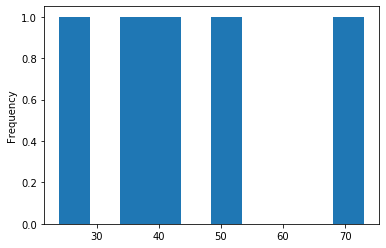

```python
df['age'].plot(kind='hist')
```

```python
df['postTestScore'].mean()
```

```
61.6
```

```python
df['postTestScore'].sum()
```

```
308
```

```python
emptyList = []
for i in df['postTestScore']:
    emptyList.append(i + 10)

print(emptyList)
```

```
[35, 104, 67, 72, 80]
```

```python
#assing a new column
df['CurvedPostTestScore'] = emptyList
```

```python
df
```

|  | first_name | last_name | age | preTestScore | postTestScore | CurvedPostTestScore |
| --- | --- | --- | --- | --- | --- | --- |
| 0 | Jason | Miller | 42 | 4 | 25 | 35 |
| 1 | Molly | Jacobson | 52 | 24 | 94 | 104 |
| 2 | Tina | Ali | 36 | 31 | 57 | 67 |
| 3 | Jake | Milner | 24 | 2 | 62 | 72 |
| 4 | Amy | Cooze | 73 | 3 | 70 | 80 |

```python
#save to excel
df.to_excel('output.xlsx')
#save to csv
df.to_csv('output.csv')
```

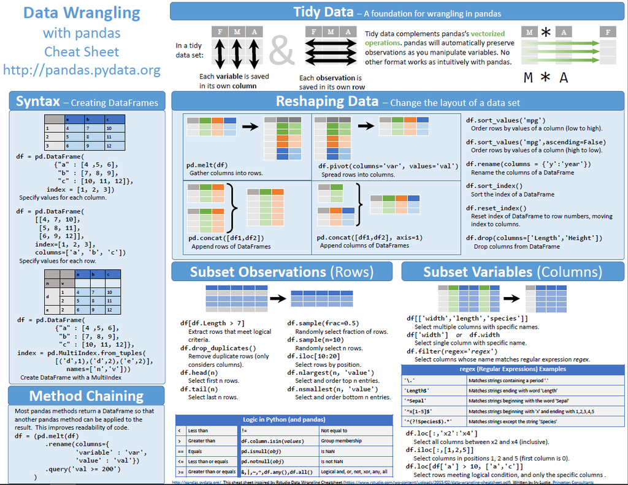

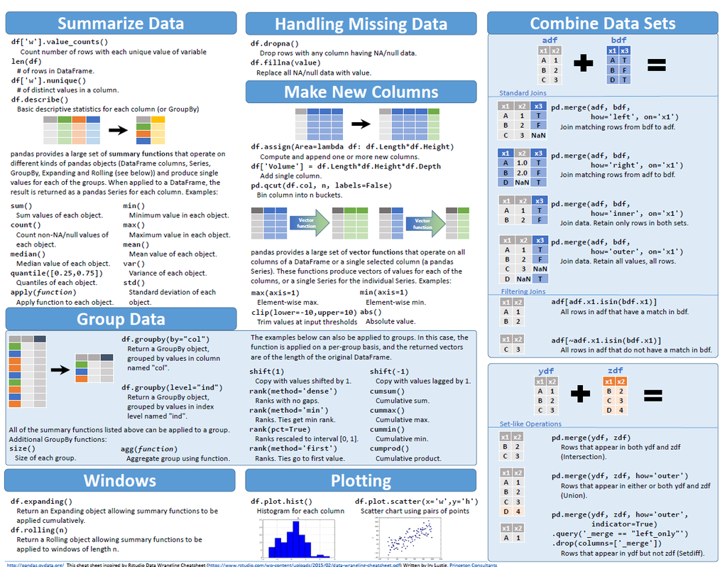